# Practica - Fechas - Diplomatura UNSAM

## Cargamos librerias

```r
library(tidyverse)
library(lubridate)
library(TTR)
```

## Cargamos la base

**Recordatorio**: Estamos trabajando con una muestra del 2% de los casos diarios, de allí que los totales diarios de casos sólo representan dicha proporción.

```r
base.covid <- readRDS("../bases/base_covid_sample.RDS")
```

## Práctica Guiada

Veamos una aplicación frecuente que se le ha dado a esta información. En tanto el registro de los casos baja los fines de semana, la información sobre la cantidad de casos ha tendido a presentarse en términos de **promedios móviles**.

- En primera instancia debemos filtrar de la base de datos aquellos casos confirmados.
- Para simplificar el ejercicio, tomemos en consideración sólo las fechas posteriores al 2020-05-01 (momento a partir del cual tenemos datos todos los días)
- Creamos la variable **dia.de.semana** para tener noción de lo que ocurre los sábados y domingos en relación al resto de la semana
- Un paso central es generar la medida de resumen de la cantidad de casos diario. Para ello agrupamos por **fecha_diagnostico** (también agrupo por **dia.de.semana** para conservar dicha variable)
- Aplicamos el `summarise()` utilizando la función **`n()`** que nos permite hacer el conteo de casos por cada variable agrupadora (en este caso, por cada día )
- Desagrupamos con `ungroup()` el objeto que obtenemos como resultado
- Filtramos también la fecha máxima (en la que se descargó la base de datos) en tanto no están completos todos los registros

```r
casos.por.dia <- base.covid %>%
  filter(clasificacion_resumen == "Confirmado",
         fecha_diagnostico >= "2020-05-01") %>%
  mutate(dia.de.semana = wday(fecha_diagnostico,label = TRUE)) %>%
  group_by(fecha_diagnostico,dia.de.semana) %>%
  summarise(casos = n()) %>%
  ungroup() %>%
  filter(fecha_diagnostico != max(fecha_diagnostico))
```

[output not shown]

```r
casos.por.dia
```

| fecha_diagnostico | dia.de.semana | casos |
| --- | --- | --- |
| 2020-05-01 | vie\\. | 4 |
| 2020-05-02 | sáb\\. | 1 |
| 2020-05-03 | dom\\. | 1 |
| 2020-05-04 | lun\\. | 1 |
| 2020-05-05 | mar\\. | 2 |
| 2020-05-06 | mié\\. | 5 |
| 2020-05-07 | jue\\. | 6 |
| 2020-05-08 | vie\\. | 1 |
| 2020-05-09 | sáb\\. | 4 |
| 2020-05-10 | dom\\. | 1 |

[output cut: 344 more lines]

**Antes de continuar con el cálculo de la media móvil. ¿Se les ocurre una forma de verificar rápidamente que ciertos días de la semana sean propensos a registrar menos casos?**

- Una vez que contamos con los casos diarios, podemos proceder a aplicar la media móvil.
- Afortunadamente, hay muchos paquetes en R que cuentan con una función específica para realizar este procedimiento. Entre ellos el paquete **TTR**, tiene la función `SMA()` (“simple moving average”) que nos permite especificar una variable y la ventana de tiempo hacia atrás para calcular los promedios.

```r
casos.media.movil <- casos.por.dia %>%
  mutate(media.movil = SMA(x = casos,n = 7))
casos.media.movil
```

| fecha_diagnostico | dia.de.semana | casos | media.movil |
| --- | --- | --- | --- |
| 2020-05-01 | vie\\. | 4 | NA |
| 2020-05-02 | sáb\\. | 1 | NA |
| 2020-05-03 | dom\\. | 1 | NA |
| 2020-05-04 | lun\\. | 1 | NA |
| 2020-05-05 | mar\\. | 2 | NA |
| 2020-05-06 | mié\\. | 5 | NA |
| 2020-05-07 | jue\\. | 6 | 2.857143 |
| 2020-05-08 | vie\\. | 1 | 2.428571 |
| 2020-05-09 | sáb\\. | 4 | 2.857143 |
| 2020-05-10 | dom\\. | 1 | 2.857143 |

[output cut: 344 more lines]

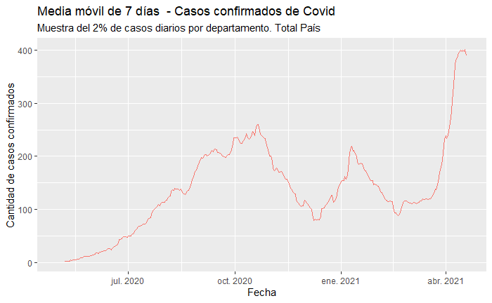

## Otros ejericios de prácitca

- Estimar a lo largo de toda la base la cantidad de **casos mensuales** según la variable de **clasificación_resumen** (“Confirmados”, “Sospechosos” y “Descartados”) . Tomar como fecha relevante la fecha del diagnóstico
- ¿Cual ha sido el tiempo promedio de tardanza del diagnóstico en cada una de las provincias? Considerar la distancia entre las variables fecha_diagnostico y fecha_inicio_sintomas
- ¿Cual fue el caso con mayor tiempo transcurrido entre la fecha de inicio de sintomas y su fecha de diagnóstico? ¿En qué departamento y provincia ocurrió? Detallar año y mes del caso en cuestión